# 表格和数据

康

## 引言

基于上一次讨论，提出一些建议和提供一些信息，如果有不同看法或不清楚的地方，可以约时间讨论或者随时留言。

## 表格调整

按照逻辑重排各列的顺序，并且所有列名均以小写字母加下划线形式命名：

ref-文献编号；

res_area-研究地区；

lca-新增列，是否采用了LCA方法；

system-稻米系统；

intervention-干预，因为系统是基础，所以干预排在系统后面；

intervention_detail-干预细节；

area-研究涉及的面积，先随意填写，后面再考虑如何规范化，例如大田试验就写”大田试验面积xx公顷”；

yield-总产量；

yield_int-沿用原来的单位和记录方式，记录单位面积产量；

imp_cat-环境影响类型；

imp_val_abs-环境影响绝对值；

imp_unit-环境影响单位；

memo-其他备注。

环境影响单位：如上所述，“function unit”改为”impact unit”，表达为”环境影响/稻田单位”，如能源消耗可能是”J/kg rice”，碳排放可能是”kg C/kg rice”，注意碳排放单位的前半部分要指明是碳量还是二氧化碳量等；如果能够将它们分成前后两部分各一列就更好了。

## 取值聚合

我统计了一些关键项目的不同取值的数量，需要通过聚合来减少取值数量（例如各种轮作是否都改为"轮作"，而把具体的轮作细节写在memo中）；对于聚合后数量仍较少的取值，可以排除在分析之外。

rice system的种类和数量分布如下：

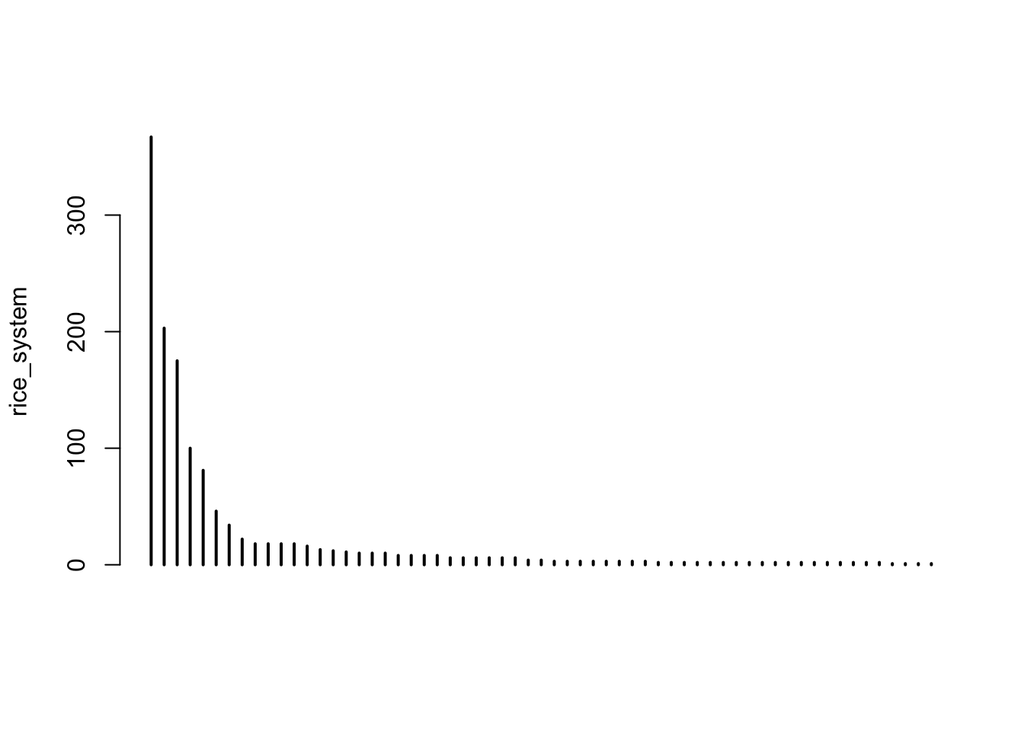

| rice_system | freq |
| --- | --- |
| irrigated rotation | 367 |
| irrigated 1 season | 203 |
| irrigated | 175 |
| flooded 1 season | 100 |
| flooded | 81 |
| rainfed 1 season | 46 |
| flooded 2 seasons | 34 |
| irrigated ratoon | 22 |
| irrigated 2 seasons (alternate wetting and drying) | 18 |
| irrigated 2 seasons (continuous flooding) | 18 |
| irrigated 2 seasons (controlled release urea) | 18 |
| irrigated 2 seasons (conventional fertilizer) | 18 |
| 1 season | 16 |
| 2 seasons | 13 |
| irrigated double season intermidient flooding | 12 |
| rice-wheat rotation | 11 |
| irrigated aquaculture | 10 |
| irrigated double | 10 |
| irrigated rotation (rice-wheat) | 10 |
| irrigated 3 seasons | 8 |
| irrigated double season | 8 |
| irrigated rotation (rice-crayfish) | 8 |
| rainfed rotation | 8 |
| corn-rice rotation cropping | 6 |
| irrigated 1 season (followed by ryegrass) | 6 |
| irrigated 1 season + cattle grazing | 6 |
| irrigated 1 season +soybean rotation (1 year rice 1 year soybean) | 6 |
| irrigated 2 seasons | 6 |
| The cropping sequence followed for the first three years in the field was lentil (Lens culinaris L.)emungbean (Vigna mungo L.)erain-fed monsoon rice. In 2013-14, the monsoon rice was followed by musta… | 6 |
| flooded two seasons | 4 |
| irrigated Rice–Wheat Double Cropping | 4 |
| 2 rotation (rice-rice-mung bean) | 3 |
| 2 rotation (rice-rice-soybean) | 3 |
| 2 rotation (rice-watermelon) | 3 |
| 3 season | 3 |
| rotation (rice-corn) | 3 |
| rotation (rice-mung bean) | 3 |
| rotation (rice-soybean) | 3 |
| rotation (rice-watermelon) | 3 |
| irrigated 2 rotation (rice-rice-mung bean) | 2 |
| irrigated 2 rotation (rice-rice-soybean) | 2 |
| irrigated 2 rotation (rice-watermelon) | 2 |
| irrigated 2 season dry | 2 |
| irrigated 2 season wet | 2 |
| irrigated 3 season | 2 |
| irrigated rotation (rice-corn) | 2 |
| irrigated rotation (rice-mung bean) | 2 |
| irrigated rotation (rice-soybean) | 2 |
| irrigated rotation (rice-watermelon) | 2 |
| rainfed 2 rotation (rice-rice-mung bean) | 2 |
| rainfed 2 rotation (rice-rice-soybean) | 2 |
| rainfed 2 rotation (rice-watermelon) | 2 |
| rainfed 2 seasons | 2 |
| rainfed rotation (rice-corn) | 2 |
| rainfed rotation (rice-mung bean) | 2 |
| rainfed rotation (rice-soybean) | 2 |
| rainfed rotation (rice-watermelon) | 2 |
| intermittent irrigation 2 seasons spring | 1 |
| intermittent irrigation 2 seasons summer | 1 |
| irrigated saline agriculture | 1 |
| rainfed 1 season, rainfed rice(June-October)-soybean/shallot(October-November)-maize/soybean/garlic/peanut/mungbean/shallot(until next June) | 1 |

```r
library(knitr)
library(kableExtra)
get_freq_col_val("rice_system") %>%
  kable() %>% kable_styling()
```

intervention的种类和数量分布如下：

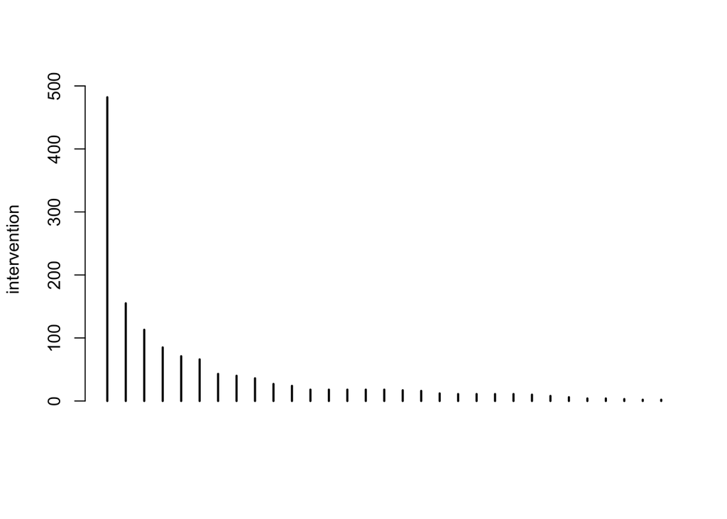

| intervention | freq |
| --- | --- |
| cropping system | 482 |
| organic | 155 |
| farm size | 113 |
| chemical fertilizer management | 85 |
| water management | 71 |
| rice-aquatic coculture | 66 |
| less chemical fertilizer | 43 |
| straw management | 40 |
| Controlled release urea | 36 |
| biochar amendment | 27 |
| smart agriculture (precision agriculture) | 24 |
| aquaculture | 18 |
| crop-livestock systems | 18 |
| film | 18 |
| non-puddling | 18 |
| pesticide management | 18 |
| compost | 17 |
| rotation | 16 |
| direct seeding | 12 |
| conventional | 11 |
| efficient farmers | 11 |
| inefficient farmers | 11 |
| mechanization | 11 |
| liquid digestate application | 10 |
| GAP | 8 |
| nitrogen fertilizer management | 6 |
| post harvest | 4 |
| rice bran and husk compost | 4 |
| no till | 3 |
| lime amendment | 2 |
| sparse planting | 2 |

```r
get_freq_col_val("intervention") %>%
  kable() %>% kable_styling()
```

impact categories的种类和数量分布如下：

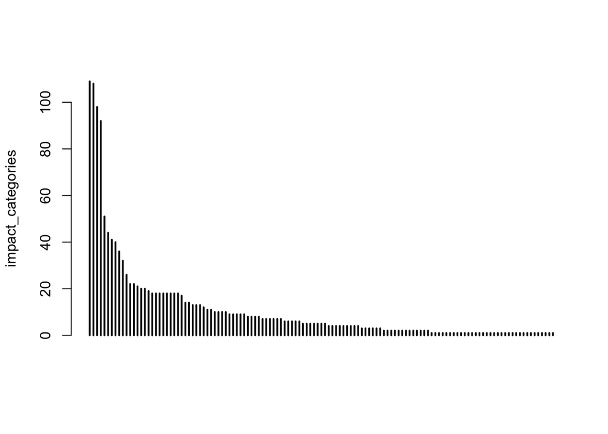

| impact_categories | freq |
| --- | --- |
| eutrophication | 109 |
| GHG emissions | 108 |
| Acidification | 98 |
| GWP100 | 92 |
| profit | 51 |
| carbon footprint | 44 |
| water depletion | 41 |
| freshwater ecotoxicity | 40 |
| GWP | 36 |
| human toxicity | 32 |
| marine eutrophication | 26 |
| acidification | 22 |
| Terrestrial Ecotoxicity | 22 |
| terrestrial ecotoxicity | 21 |
| marine ecotoxicity | 20 |
| photochemical oxidant formation (kg NMVOC) | 20 |
| fossil depletion (kg oil eq) | 19 |
| agricultural land occupation (m2a) | 18 |
| freshwater aquatic ecotoxicity | 18 |
| Ionising radiation (kBq U235 eq) | 18 |
| metal depletion (kg Fe eq) | 18 |
| ozone depletion (g CFC-11 eq) | 18 |
| particulate matter (kg PM10 eq) | 18 |
| total non-renewable energy (MJ) | 18 |
| total renewable energy (MJ) | 18 |
| Abiotic Depletion potential | 17 |
| Fossil Fuels Abiotic Depletion potential | 14 |
| non-renewable energy depletion (MJ) | 14 |
| nitrogen footprint | 13 |
| ozone depletion | 13 |

[output cut: 97 more lines]

```r
get_freq_col_val("impact_categories") %>%
  kable() %>% kable_styling()
```

country的种类和数量分布如下（这个不是那么重要，可以先放着）：

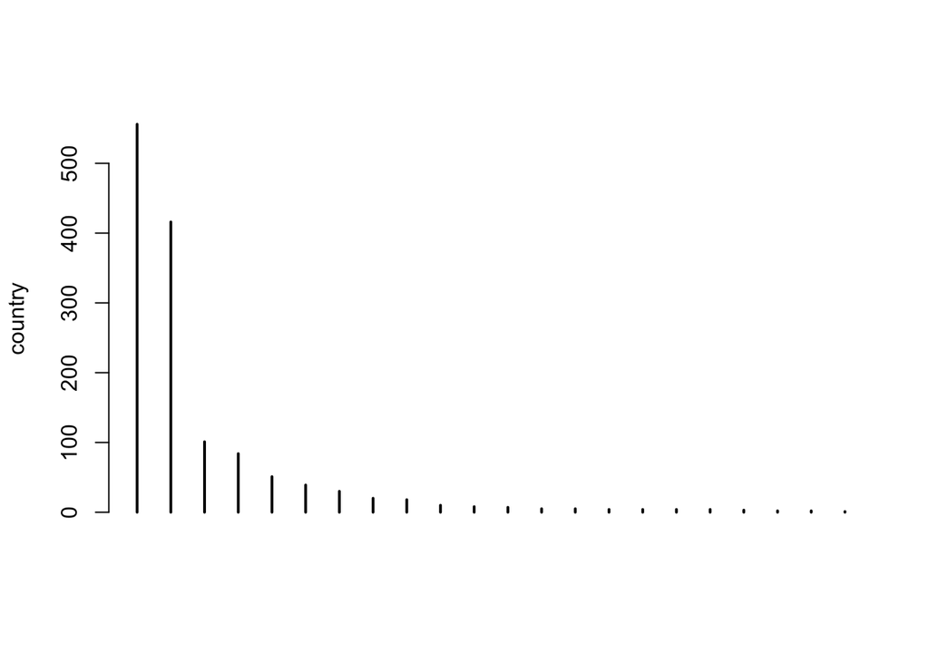

| country | freq |
| --- | --- |
| Iran | 556 |
| China | 416 |
| Thailand | 101 |
| Italy | 84 |
| Japan | 51 |
| South Korea | 39 |
| Bangladesh | 30 |
| India | 20 |
| Brazil | 18 |
| vietnam | 10 |
| Taiwan | 8 |
| Malaysia | 7 |
| Thailand (north) | 5 |
| Thailand (northeast) | 5 |
| Afghanistan | 4 |
| Greece | 4 |
| Myanmar | 4 |
| the Philipines | 4 |
| Korea | 3 |
| Spain | 2 |
| Vietnam | 2 |
| china | 1 |

```r
get_freq_col_val("country") %>%
  kable() %>% kable_styling()
```

## 分析

虽然因为关键变量（大米系统、干预、影响种类）还没聚合，导致种类非常多，但是先以GWP100为例，看看不同系统或不同的干预下，GWP100是多少。这也有助于我们考虑有些子类要不要合并，例如，如果两个比较相似的大米系统子类A和B，GWP100的差异却很大，那么可能就不应该合并。

此外，需要注意的是，由于单位尚未统一，所以尽管我们已经将数据限制在GWP100范围内了，但是原数据其实是不太可直接比较的。这部分涉及的单位包括：1 kg of rice，1 kg of rice produced (kgCO2eq)，1 kg of rice grain (kg CO2-eq)，1 ton of rice grain (kg CO2 eq)，1 ton of rice grain (ton CO2 eq)，1 ha of rice-wheat rotation system (kg CO2 eq)，1 kg of refined rice packed (kg CO2 eq.)，1 ton of rice，1 ha of rice-planted area，1 ha of rice (kg CO2 eq)，1 ha of rice，1 ton of rice (14% moisture)。由于1 ton of rice和1 kg of rice最多，所以我只保留以这两个为单位的数据，并且将以"1 kg of rice"为单位的数据的环境影响乘以1000，以和"1 ton of rice"数据统一。

系统是基础，所以我们先看不同系统下的GWP100：可以看出flooded系统的GWP100本身就比较高，因此在评估干预的影响时，不应该直接拿不同系统的值比较。具体举个例子，不可以直接拿rain fed的有机农业GWP100和flooded的GWP100进行比较。

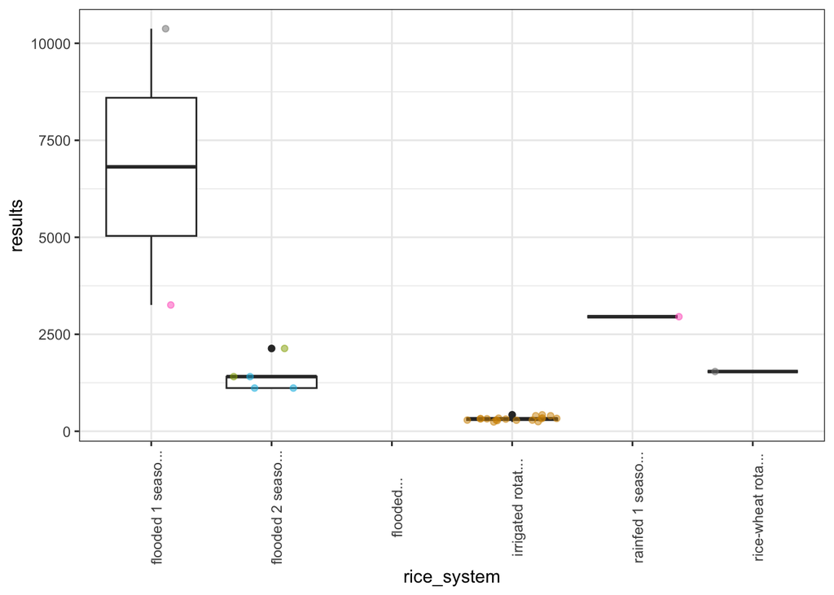

```r
raw_gwp100 %>%
  mutate(
    rice_system = paste0(substr(rice_system, 1, 15), "...")
  ) %>%
  ggplot(aes(rice_system, results)) +
  geom_boxplot() +
  geom_jitter(aes(col = intervention), alpha = 0.5) +
  theme_bw() +
  theme(
    axis.text.x = element_text(angle = 90),
    legend.position = "none"
  )
```

然后看干预措施下的GWP100：

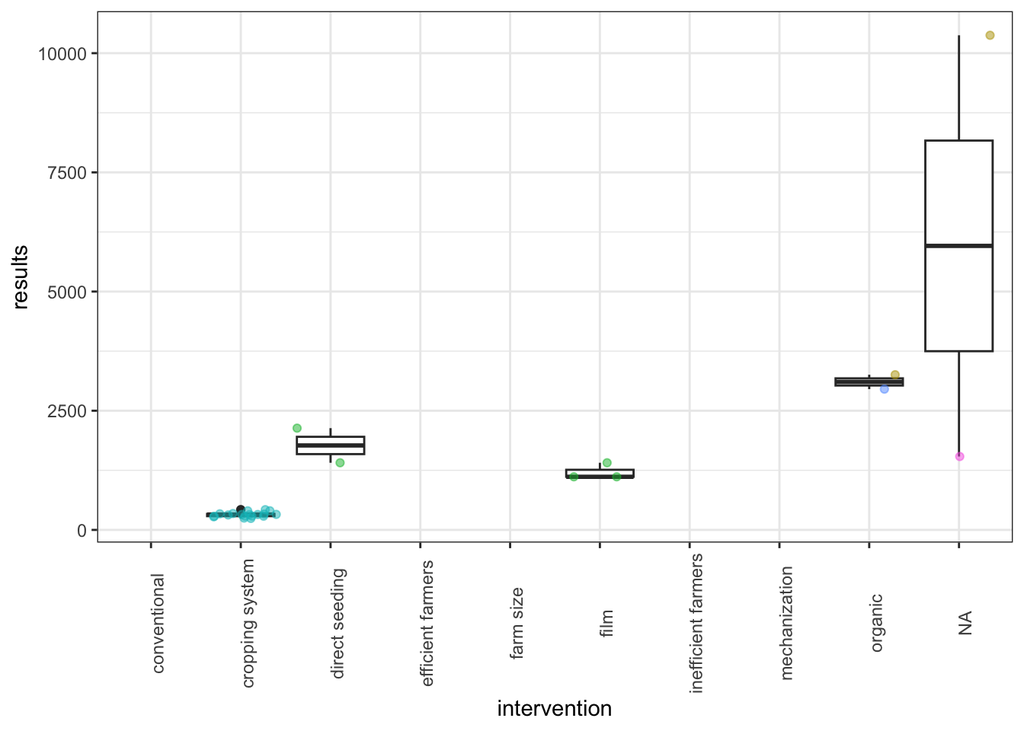

```r
ggplot(raw_gwp100, aes(intervention, results)) +
  geom_boxplot() +
  geom_jitter(aes(col = rice_system), alpha = 0.5) +
  theme_bw() +
  theme(
    axis.text.x = element_text(angle = 90),
    legend.position = "none"
  )
```

## 其他需求

- 有些没写是rain fed还是灌溉，则根据国家来推测：要在备注中，或者另开一栏说明这是推测的还是原文中写的。
- 能否给我一个流程信息，说明一下大米处理不同过程的产品和你的function unit中的词语是如何对应的（grain，rice，rice packed等）。

## 一些问题

- 原表格中的”1_ton_result”列是否可以通过表示环境影响数值的”Result”列计算得到？
- 需要确认”GHG”这种环境影响是否都以”二氧化碳当量”为单位，如果是的话，那么它们一般是按照GWP100标准来计算的。

## 一些回答

- GWP100和500之间无法直接转化，因为不同温室气体的GWP100和500不同。例如，甲烷GWP100是28-36，和GWP500是7-10，一氧化二氮的GWP100约为273，GWP500约为153。GWP500的结果并不多，所以暂时不是大问题。